# Vis Assignment 2 - Mapping

Aron Lesser

9/18/2020

# Loading a map of world countries

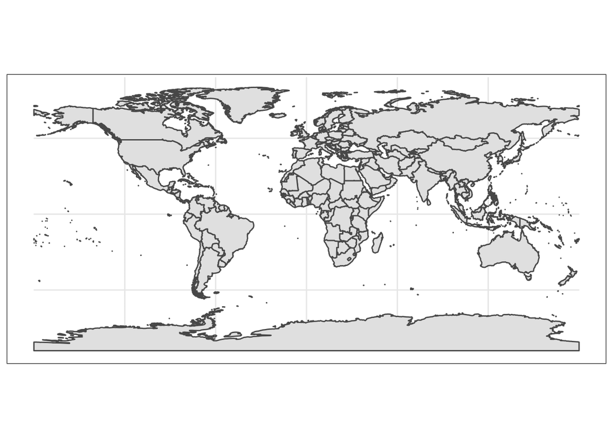

```r
#ne_countries, ne_states, ne_coastlines

world <- ne_countries(scale = 50, returnclass = "sf")


world_map <- ggplot(world) +
  geom_sf() +
  theme_bw()

world_map
```

# South America

Here, I filter for South America

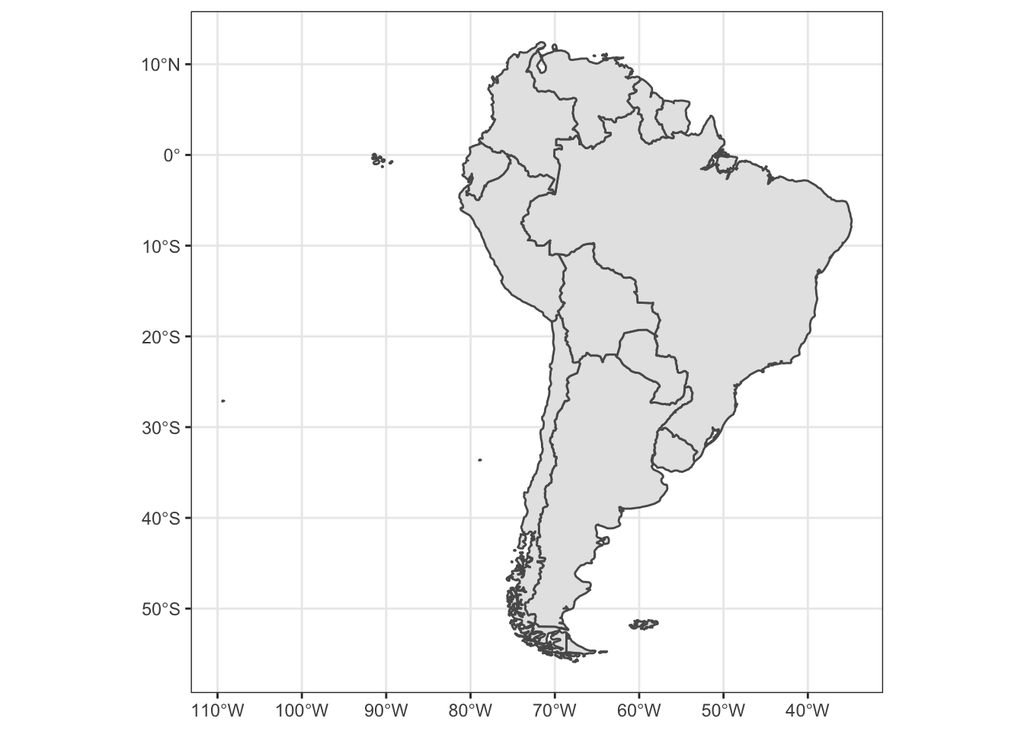

```r
sa_countries <- world %>%
  filter(continent == "South America")

sa_map <- ggplot(sa_countries) +
  geom_sf() +
  theme_bw()

sa_map
```

# States Brasil

I was playing around with loading states within a country and changing the background color, but will not use this in my assignment.

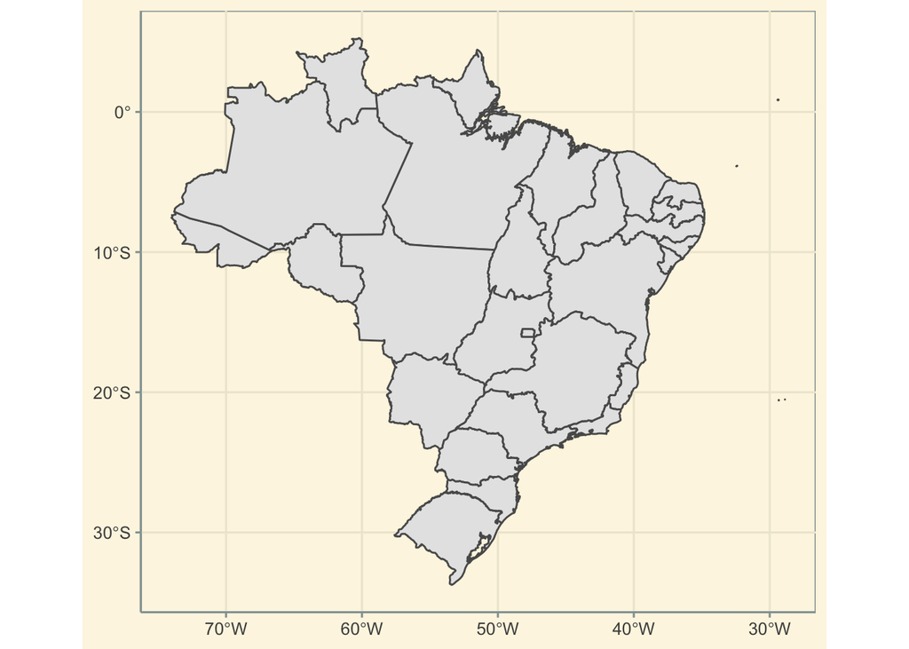

```r
brasil_states <- ne_states(country = "Brazil", returnclass = "sf")

brasil_map <- ggplot(brasil_states) +
  geom_sf() +
  theme_solarized()

brasil_map
```

# Maps of South America with Alterations to Coordinate Systems

```r
SA_brasil_Albers <- "+proj=aea +lat_1=-2 +lat_2=-22 +lat_0=-12 +lon_0=-54 +x_0=0 +y_0=0 +a=6378160 +b=6356537.557298475 +units=m +no_defs"

SA_brasil_lambert <- "+proj=laea +lat_0=-13 +lon_0=-42 +x_0=600000 +y_0=600000 +ellps=GRS80 +units=m +no_defs"

SA_argentina_bicontinental <- "+proj=stere +lat_0=-90 +lat_ts=-90 +lon_0=-63 +k=1 +x_0=0 +y_0=0 +ellps=WGS84 +datum=WGS84 +units=m +no_defs"

SA_equal_area_conic <- "+proj=aea +lat_1=-5 +lat_2=-42 +lat_0=-32 +lon_0=-60 +x_0=0 +y_0=0 +ellps=aust_SA +units=m +no_defs"
```

# Brasil Albers

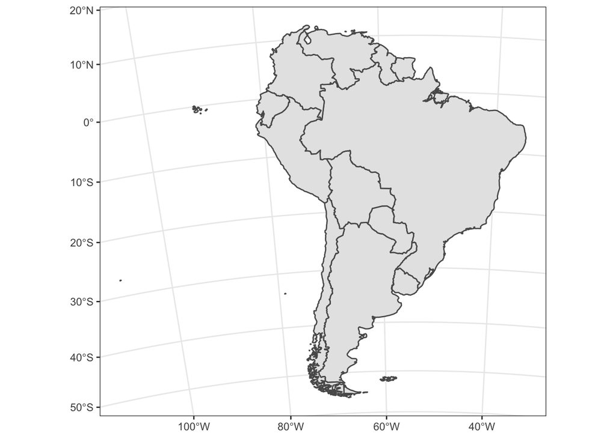

```r
ggplot(sa_countries) +
  geom_sf() +
  coord_sf(crs = SA_brasil_Albers) +
  theme_bw()
```

# Brasil Lambert

I notice clear distortions in the southern tip of the continent with the lambert projection.

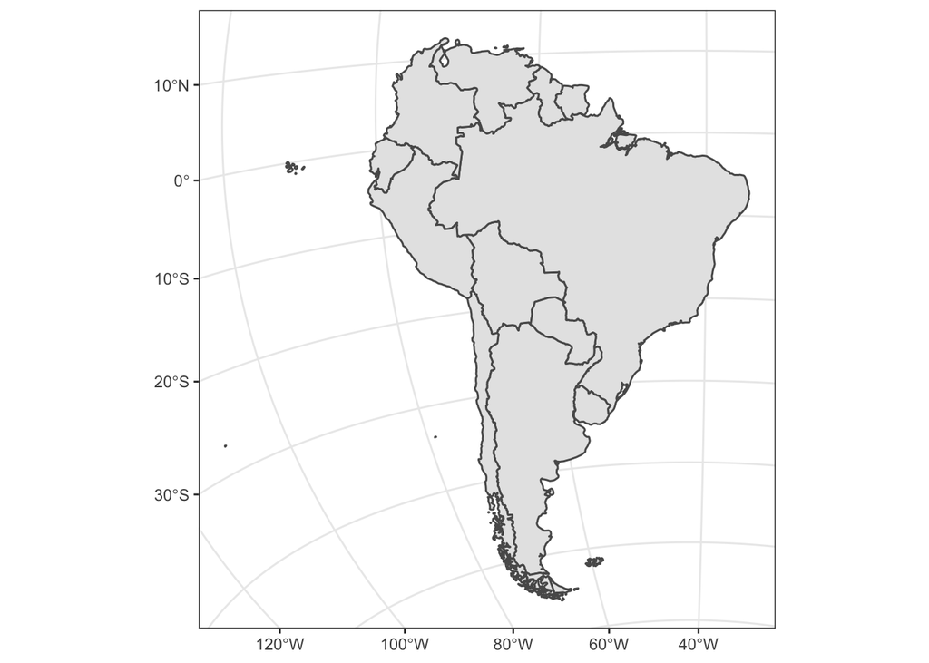

```r
ggplot(sa_countries) +
  geom_sf() +
  coord_sf(crs = SA_brasil_lambert) +
  theme_bw()
```

# Argentina Bicontinental Polar

The Argentinna-focused Polar projection distorts the northern side of the continent - or the southern, depending on how we think about it.

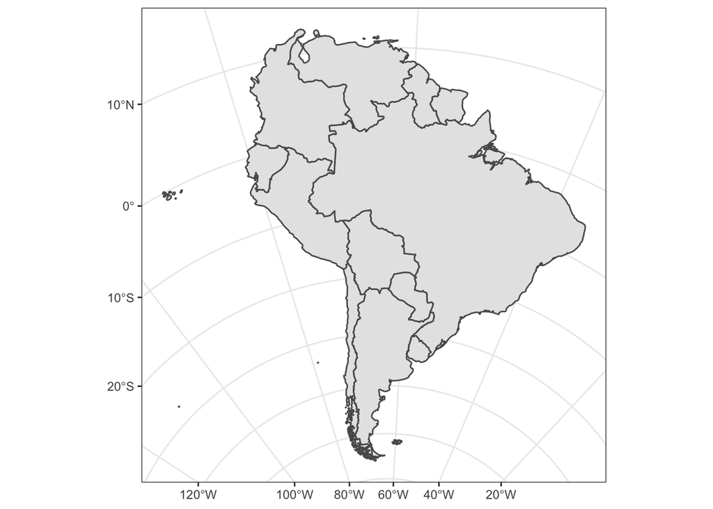

```r
ggplot(sa_countries) +
  geom_sf() +
  coord_sf(crs = SA_argentina_bicontinental) +
  theme_bw()
```

# South America Equal Area

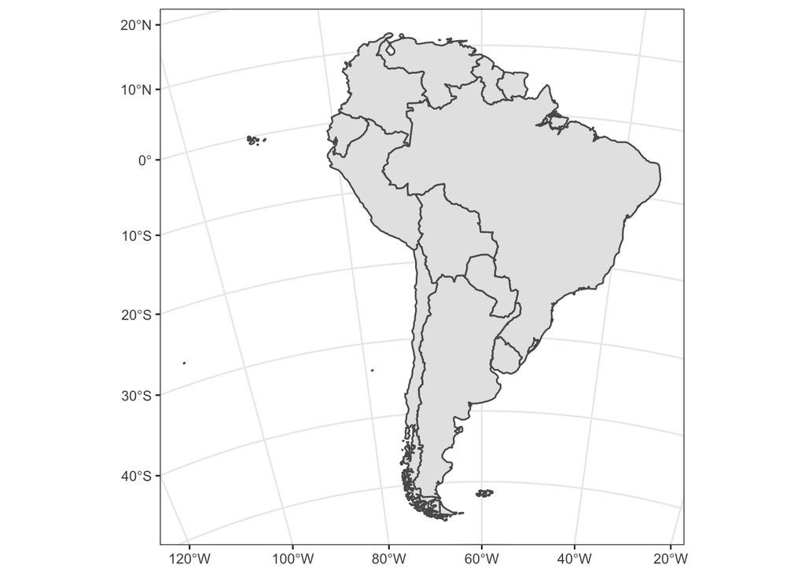

```r
ggplot(sa_countries) +
  geom_sf() +
  coord_sf(crs = SA_equal_area_conic) +
  theme_bw()
```

# Countries Transformed

```r
countries_transformed <- sa_countries %>%
  st_transform(crs = SA_brasil_Albers)
```

I decided to use the Albers because it is likely the one that people from the United States are accustomed to seeing.

# Adding GDP

I downloaded per-capita GDP data from the World Bank and left-joined it using the following code:

```r
GDP_SA <- read_csv("World Bank Per Capita GDP2.csv")
GDP_countries <-countries_transformed %>%
  left_join(GDP_SA, by = c("name" = "Country Name")) %>%
  select(name, "GDP", "Population")
```

# Chloropleth Map of South America with Per Capita GDP

Here, I plot it as a chloropleth map, adjusting the breaks and lables to fit the range of GDPs. Unfortunately, the World Bank does not have data for Venezuela, which is displayed in grey.

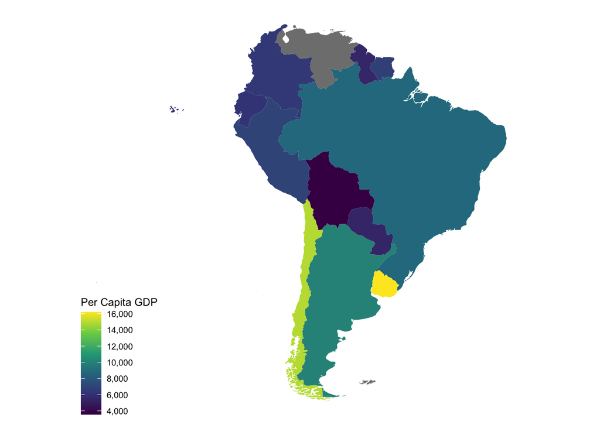

```r
brs <- seq(0, 20000, by=2000)
labls <- formatC(seq(0, 20000, by=2000), big.mark = ",", format = "f", digits = 0)


ggplot(GDP_countries, aes(fill = GDP)) +
  geom_sf(color = NA) +
  scale_fill_viridis_c(
    name = "Per Capita GDP",
    breaks = brs,
    labels = labls) +
  theme_map() +
  theme(legend.background = element_blank())
```

## Cartogram

### Continuous, based on GDP

In this map, I distort the countries based on the per-capita GDPs. As we can see, Chile and Uruguay seem much bigger and Brazil shrinks.

```r
SA_cartogram_cont <- GDP_countries %>%
  cartogram_cont("GDP")
```

```
## Mean size error for iteration 1: 3.89918726098842
```

```
## Mean size error for iteration 2: 2.55676682452402
```

```
## Mean size error for iteration 3: 1.91733811877798
```

```
## Mean size error for iteration 4: 1.60297760559147
```

```
## Mean size error for iteration 5: 1.44642587423141
```

```
## Mean size error for iteration 6: 1.35609385716772
```

```
## Mean size error for iteration 7: 1.29069568662227
```

```
## Mean size error for iteration 8: 1.23974533952875
```

```
## Mean size error for iteration 9: 1.20112800453882
```

```
## Mean size error for iteration 10: 1.16937501098687
```

```
## Mean size error for iteration 11: 1.14275869928933
```

```
## Mean size error for iteration 12: 1.12068238802002
```

```
## Mean size error for iteration 13: 1.10253432582761
```

```
## Mean size error for iteration 14: 1.08765905857872
```

```
## Mean size error for iteration 15: 1.07547866462366
```

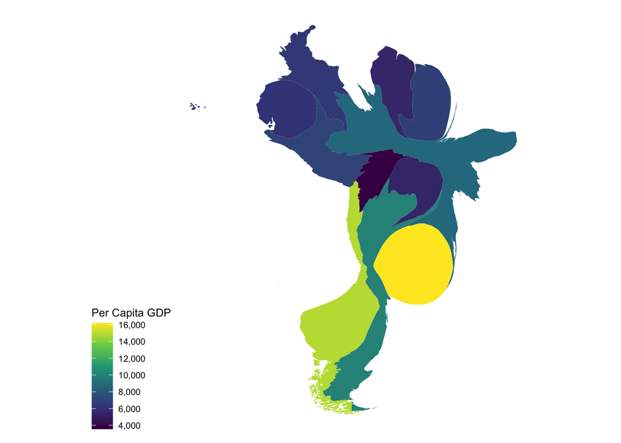

```r
brs <- seq(0, 20000, by=2000)
labls <- formatC(seq(0, 20000, by=2000), big.mark = ",", format = "f", digits = 0)


ggplot(SA_cartogram_cont, aes(fill = GDP)) +
  geom_sf(color = NA) +
  scale_fill_viridis_c(
    name = "Per Capita GDP",
    breaks = brs,
    labels = labls) +
  theme_map() +
  theme(legend.background = element_blank())
```

### Non-Continuous

In this non-continous cartogram, I adjust country size based on per-capita GDP. This may be an effective graphic because it demonstrates that large countries such as Brazil have relatively similar per-capita GDPs to many of the region’s other countries. It also creates the contrast between Uruguray and Brazil, which I find visually interesting.

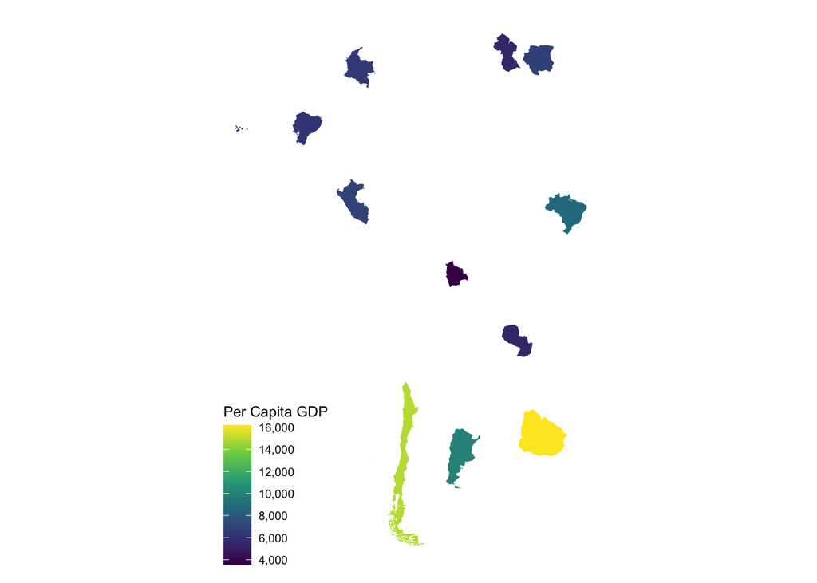

```r
SA_cartogram_ncont <- GDP_countries %>%
  cartogram_ncont("GDP")


brs <- seq(0, 20000, by=2000)
labls <- formatC(seq(0, 20000, by=2000), big.mark = ",", format = "f", digits = 0)


ggplot(SA_cartogram_ncont, aes(fill = GDP)) +
  geom_sf(color = NA) +
  scale_fill_viridis_c(
    name = "Per Capita GDP",
    breaks = brs,
    labels = labls) +
  theme_map() +
  theme(legend.background = element_blank())
```

### Non-Continuous with Population

This is an interesting comparison to the above cartogram, though it does not tell a strong story because the countries in the region are, for the most part, closely proportional in land size and population.

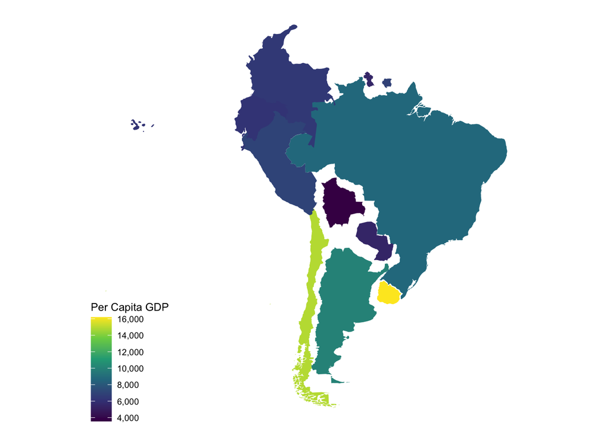

```r
SA_cartogram_ncont <- GDP_countries %>%
  cartogram_ncont("Population")


brs <- seq(0, 20000, by=2000)
labls <- formatC(seq(0, 20000, by=2000), big.mark = ",", format = "f", digits = 0)


ggplot(SA_cartogram_ncont, aes(fill = GDP)) +
  geom_sf(color = NA) +
  scale_fill_viridis_c(
    name = "Per Capita GDP",
    breaks = brs,
    labels = labls) +
  theme_map() +
  theme(legend.background = element_blank())
```

### Proportional Symbol

In this proportional symbol map, I highlight GDP with circle sizes. I do not find this visual as effective as some of the above for this particular type of data. I was not able to understand why bolivia’s gdp does not display.

```r
GDP_centeroids <- GDP_countries %>%
  st_centroid()
```

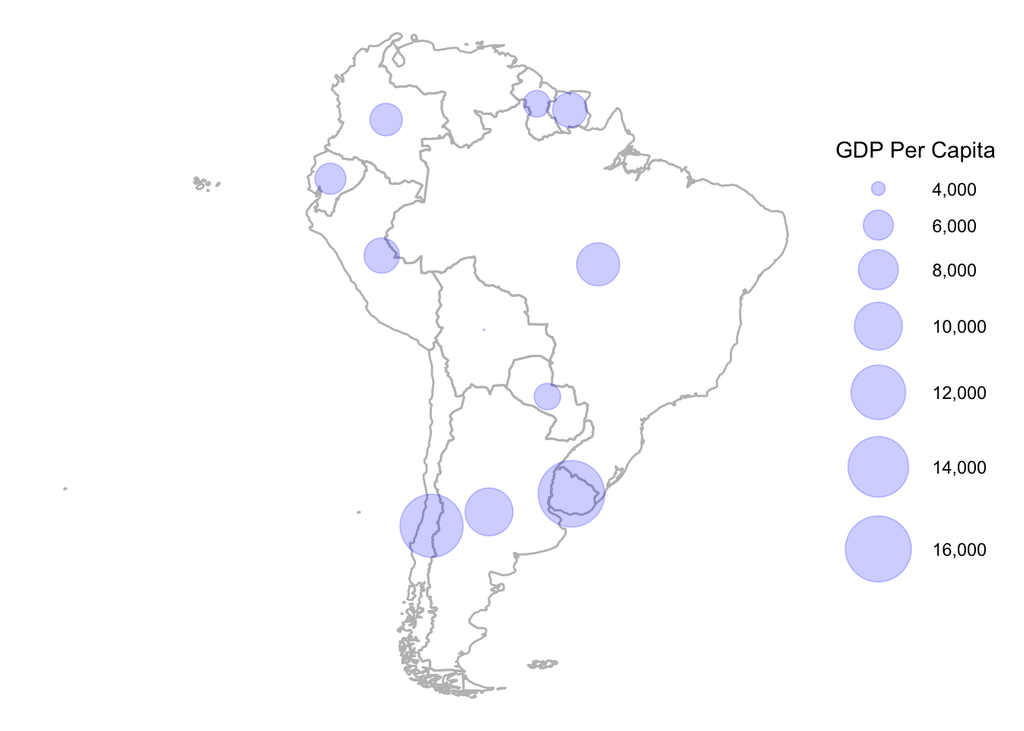

```r
brs <- seq(0, 20000, by=2000)
labls <- formatC(seq(0, 20000, by=2000), big.mark = ",", format = "f", digits = 0)


ggplot(countries_transformed) +
  geom_sf(fill = NA, color = "gray") +
  geom_sf(data = GDP_centeroids,
          aes(size = GDP),
          alpha = 0.2, color = "blue") +
  scale_size_continuous(name = "GDP Per Capita",
    breaks = seq(0, 20000, by=2000),
    labels = formatC(seq(0, 20000, by=2000), big.mark = ",", format = "f", digits = 0),
    range = c(0, 15)) +
  theme_void()
```

### Dorling

I was unable to get my Dorling proejction to work, but I kept the code in to review later.

```r
#GDP_countries$area<- NA
#GDP_countries$area<- GDP_countries$geometry

#SA_cartogram_dorling <- GDP_countries %>%
#  cartogram_dorling("Population")


#brs <- seq(0, 20000, by=2000)
#labls <- formatC(seq(0, 20000, by=2000), big.mark = ",", format = "f", digits = 0)


#ggplot(SA_cartogram_dorling, aes(fill = GDP)) +
 # geom_sf(color = NA) +
  #scale_fill_viridis_c(
   # name = "Per Capita GDP",
    #breaks = brs,
    #labels = labls) +
  #theme_map() +
  #theme(legend.background = element_blank())
```